# Statistical machine learning, Lab 9

# Decision trees for regression

The aim of this lab is to learn to use decision tree models for regression and for determining relative importance of different variables in predicting the values of the response variable.

## R packages we use in the lab

We are going to use `tidymodels` framework and `rpart` package for model fitting, additionally we use the package `rpart.plot` for visualizing the fitted trees.

## Datasets of the lab

We are going to use `Auto` dataset from `ISLR` package

## Regression Trees

Our first exercise is about using `rpart::rpart()` command for fitting regression tree models. The most important parameters of the command are as follows:

- `formula=response~pred1+...+predn` for indicating response variable and predictors.
- `data=train_df` - data frame for fitting the tree
- `method="anova"` for regression, `method="class"` for classification
- `cp=number` - complexity parameter between 0 and 1, default is 0.01. If internal cross-validation is used for model selection, then it may be a good idea to reduce this number (or even make it to be equal to 0) when fitting a tree.
- `xval=10` - how many folds to use in the case of applying cross-validation, 10 is the default value. Use `xval=0` if external means (like `tune_grid` in the case of using `tidymodels` framework) for choosing `cp` variable are used
- `minsplit=10` - minimal number of observations in a region which is considered for splitting. Default is 20.
- `minbucket=10` - minimal number of observations in a leaf.

After fitting a model with `model=rpart::rpart(...)` it is possible to see a lot of information about the fit with `summary(model)`; a table with different values for complexity parameter with corresponding complexity of the tree (number of splits) and cross-validation error (`xerror`) can be obtained by `model$cptable`, a nice graphical representation for trees with relatively small number of splits can be obtained by `rpart.plot::rpart.plot(model)`. If we want to prune a complicated tree based on internal crossvalidation results for partial plotting, it is possible to use the command `rpart::prune(model,cp=value)`.

### Exercise 1

Consider `Auto` dataset. Our aim is to predict `mpg` by `horsepower` by a regression tree. Use the full data set after removing the `name` variable as a training set. Use `set.seed(20241031)` just before fitting an regression tree model to `mpg` with respect to all other variables by using `cp=0.000001` and `minsplit=10`. Look at the crossvalidation results. How many leafs this model has? How many leafs has the model with the best cp value? Which are 5 most important variables? Produce a graph of the part of the decision tree with first 15 splits

```r
set.seed(20241031)
mod1=rpart::rpart(mpg~.,data=ISLR::Auto|>select(-name),cp=0.000001,minsplit=10,method="anova")
#mod1$cptable
cp_15=as_tibble(mod1$cptable) |> filter(nsplit==14)|>pull(CP)
mod1$variable.importance
```

```
## displacement       weight   horsepower    cylinders       origin acceleration
##    17648.397    16316.437    13925.044    13482.965     8102.659     6498.450
##         year
##     2969.353
```

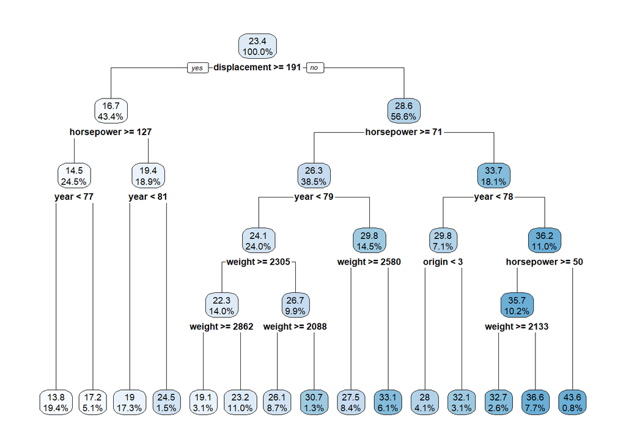

```r
rpart.plot::rpart.plot(rpart::prune(mod1,cp=cp_15),digits=3)
```

```r
cp_min=as_tibble(mod1$cptable) |> filter(xerror==min(xerror))|>slice(1)|>pull(CP)
final_tree1=rpart::prune(mod1,cp=cp_min)
final_tree1
```

```
## n= 392
##
## node), split, n, deviance, yval
##       * denotes terminal node
##
##    1) root 392 23818.990000 23.44592
##      2) displacement>=190.5 170  2210.188000 16.66000
##        4) horsepower>=127 96   457.066200 14.51875
##          8) year< 76.5 76   238.352000 13.82237
##           16) weight>=4358.5 31    91.596770 12.85484
##             32) year< 74.5 26    45.884620 12.34615
##               64) year< 70.5 5    14.800000 10.80000 *
##               65) year>=70.5 21    16.285710 12.71429 *
##             33) year>=74.5 5     4.000000 15.50000 *
##           17) weight< 4358.5 45    97.744440 14.48889
##             34) weight>=3533.5 38    59.368420 14.23684 *
##             35) weight< 3533.5 7    22.857140 15.85714 *
##          9) year>=76.5 20    41.805500 17.16500
##           18) weight>=3947.5 10     5.309000 15.99000 *
##           19) weight< 3947.5 10     8.884000 18.34000 *
##        5) horsepower< 127 74   741.954100 19.43784
##         10) year< 80.5 68   313.417600 18.99412
##           20) displacement>=241 29   147.921400 17.91724
##             40) year< 78.5 26    78.783460 17.44231
##               80) acceleration>=16.75 12    16.750000 16.25000
##                160) year< 75.5 8     2.000000 15.50000 *
##                161) year>=75.5 4     1.250000 17.75000 *
##               81) acceleration< 16.75 14    30.352140 18.46429 *
##             41) year>=78.5 3    12.446670 22.03333 *
##           21) displacement< 241 39   106.859000 19.79487
##             42) weight>=3434.5 8    11.395000 18.22500 *
##             43) weight< 3434.5 31    70.660000 20.20000
##               86) displacement>=231.5 10    16.889000 19.31000
##                172) year< 74.5 5     1.200000 18.40000 *
##                173) year>=74.5 5     7.408000 20.22000 *
##               87) displacement< 231.5 21    42.078100 20.62381 *
##         11) year>=80.5 6   263.413300 24.46667 *
##      3) displacement< 190.5 222  7785.902000 28.64234
##        6) horsepower>=70.5 151  3347.560000 26.28013
##         12) year< 78.5 94  1222.092000 24.12021
```

[output cut: 51 more lines]

```
##             60) weight>=2132.5 10    58.740000 32.70000
##              120) displacement< 101.5 4    12.140000 30.80000 *
##              121) displacement>=101.5 6    22.533330 33.96667 *
##             61) weight< 2132.5 30   462.115000 36.65000
##              122) weight< 2067.5 22   240.889500 35.69545
##                244) acceleration>=15.1 19   149.025300 35.08421
##                  488) acceleration< 15.85 3     9.246667 31.96667 *
##                  489) acceleration>=15.85 16   105.154400 35.66875
##                    978) weight>=1969 11    68.407270 34.84545
##                     1956) acceleration>=17.45 6    35.435000 33.65000 *
##                     1957) acceleration< 17.45 5    14.108000 36.28000 *
##                    979) weight< 1969 5    12.888000 37.48000 *
##                245) acceleration< 15.1 3    39.806670 39.56667 *
##              123) weight>=2067.5 8   146.055000 39.27500 *
##           31) horsepower< 50 3     0.780000 43.60000 *
```

In the case of tidymodels framework the regression tree model can be specified with `decision_tree(mode="regression", ... )` command. Additional parameters `cost_complexity` (corresponds to the `cp` parameter in `rpart`), `tree_depth` and `min_n` (minimal number of observations in a node) can be specified (or tuned, when set equal to `tune()`).

### Exercise 2

Use tidymodels framework and parameter tuning to determine the best cp value for a decision tree model.

```r
rec2=recipe(mpg~.,data=ISLR::Auto)|>step_select(-name)
tree_spec=decision_tree(mode="regression",cost_complexity=tune(),min_n=5)|>set_engine("rpart",xval=0)
wf2=workflow()|>add_recipe(rec2)|>add_model(tree_spec)
cvdata=vfold_cv(ISLR::Auto,v=10)
grid=data.frame(cost_complexity=10^seq(-6,0,length.out=11))
tune_result=wf2|>tune_grid(cvdata,grid=grid,metrics=metric_set(rmse))
show_best(tune_result)
```

| cost_complexity | .metric | .estimator | mean | n | std_err | .config |
| --- | --- | --- | --- | --- | --- | --- |
| 0.0039810717 | rmse | standard | 3.528111 | 10 | 0.2588149 | Preprocessor1_Model07 |
| 0.0010000000 | rmse | standard | 3.646510 | 10 | 0.2665422 | Preprocessor1_Model06 |
| 0.0002511886 | rmse | standard | 3.670332 | 10 | 0.2745570 | Preprocessor1_Model05 |
| 0.0158489319 | rmse | standard | 3.674282 | 10 | 0.1801090 | Preprocessor1_Model08 |
| 0.0000010000 | rmse | standard | 3.691239 | 10 | 0.2765153 | Preprocessor1_Model01 |

```r
fit=finalize_workflow(wf2,select_best(tune_result,metric="rmse"))|>fit(data=ISLR::Auto)
fit|>extract_fit_engine()
```

```
## n= 392
##
## node), split, n, deviance, yval
##       * denotes terminal node
##
##  1) root 392 23818.99000 23.44592
##    2) displacement>=190.5 170  2210.18800 16.66000
##      4) horsepower>=127 96   457.06620 14.51875
##        8) year< 76.5 76   238.35200 13.82237 *
##        9) year>=76.5 20    41.80550 17.16500 *
##      5) horsepower< 127 74   741.95410 19.43784
##       10) year< 81.5 72   384.63780 19.14444 *
##       11) year>=81.5 2   128.00000 30.00000 *
##    3) displacement< 190.5 222  7785.90200 28.64234
##      6) horsepower>=70.5 151  3347.56000 26.28013
##       12) year< 78.5 94  1222.09200 24.12021
##         24) weight>=2305 55   413.66840 22.28545
##           48) weight>=2861.5 12    50.04917 19.05833 *
##           49) weight< 2861.5 43   203.77160 23.18605 *
##         25) weight< 2305 39   362.16770 26.70769 *
##       13) year>=78.5 57   963.73890 29.84211
##         26) weight>=2580 33   224.99880 27.46061 *
##         27) weight< 2580 24   294.23330 33.11667 *
##      7) horsepower< 70.5 71  1803.77900 33.66620
##       14) year< 77.5 28   280.25000 29.75000
##         28) origin< 2.5 16   145.50000 28.00000 *
##         29) origin>=2.5 12    20.41667 32.08333 *
##       15) year>=77.5 43   814.47860 36.21628
##         30) horsepower>=50 40   637.87380 35.66250
##           60) weight>=2132.5 10    58.74000 32.70000 *
##           61) weight< 2132.5 30   462.11500 36.65000 *
##         31) horsepower< 50 3     0.78000 43.60000 *
```

### Exercise 3

Consider the problem of approximating the function which is 1 in the unit circle and 0 otherwise by a regression tree. Fit the regression tree by `rpart::rpart()` to the data in `lab9.csv` with default parameters, visualize the shape of the obtained model with `ggplot2` package and command `geom_raster()`. For producing the graph, use `expand_grid(x1=seq(-1,1,length.out=40),x2=seq(-1,1,length.out=40))` to make a set of values for which to obtain predictions.

```r
df3=read_csv("lab9.csv",show_col_types=FALSE)
mod3=rpart::rpart(y~.,data=df3,method="anova")
mod3
```

```
## n= 1000
##
## node), split, n, deviance, yval
##       * denotes terminal node
##
##   1) root 1000 146.9590000 0.8210000
##     2) x1>=0.7902693 110  27.1727300 0.4454545
##       4) x2>=0.5353169 27   0.0000000 0.0000000 *
##       5) x2< 0.5353169 83  20.0722900 0.5903614
##        10) x2< -0.4990101 22   0.0000000 0.0000000 *
##        11) x2>=-0.4990101 61   9.6393440 0.8032787
##          22) x2>=0.1968325 19   4.7368420 0.4736842 *
##          23) x2< 0.1968325 42   1.9047620 0.9523810 *
##     3) x1< 0.7902693 890 102.3551000 0.8674157
##       6) x1< -0.6294254 176  42.5454500 0.5909091
##        12) x2>=0.6866414 29   0.0000000 0.0000000 *
##        13) x2< 0.6866414 147  30.4217700 0.7074830
##          26) x2< -0.5728578 26   3.3846150 0.1538462 *
##          27) x2>=-0.5728578 121  17.3553700 0.8264463
##            54) x1< -0.9176088 34   8.2352940 0.4117647
##             108) x2>=0.3059382 12   0.0000000 0.0000000 *
##             109) x2< 0.3059382 22   5.0909090 0.6363636
##               218) x2< -0.2352059 7   0.8571429 0.1428571 *
##               219) x2>=-0.2352059 15   1.7333330 0.8666667 *
##            55) x1>=-0.9176088 87   0.9885057 0.9885057 *
##       7) x1>=-0.6294254 714  43.0364100 0.9355742
##        14) x2< -0.8868922 33   8.0606060 0.4242424
##          28) x1>=0.4495122 8   0.0000000 0.0000000 *
##          29) x1< 0.4495122 25   6.1600000 0.5600000
##            58) x2< -0.9284261 15   3.3333330 0.3333333 *
##            59) x2>=-0.9284261 10   0.9000000 0.9000000 *
##        15) x2>=-0.8868922 681  25.9295200 0.9603524
##          30) x2>=0.8737312 36   9.0000000 0.5000000
##            60) x1>=0.3988292 9   0.0000000 0.0000000 *
##            61) x1< 0.3988292 27   6.0000000 0.6666667
##             122) x1< -0.24323 10   1.6000000 0.2000000 *
##             123) x1>=-0.24323 17   0.9411765 0.9411765 *
##          31) x2< 0.8737312 645   8.8744190 0.9860465 *
```

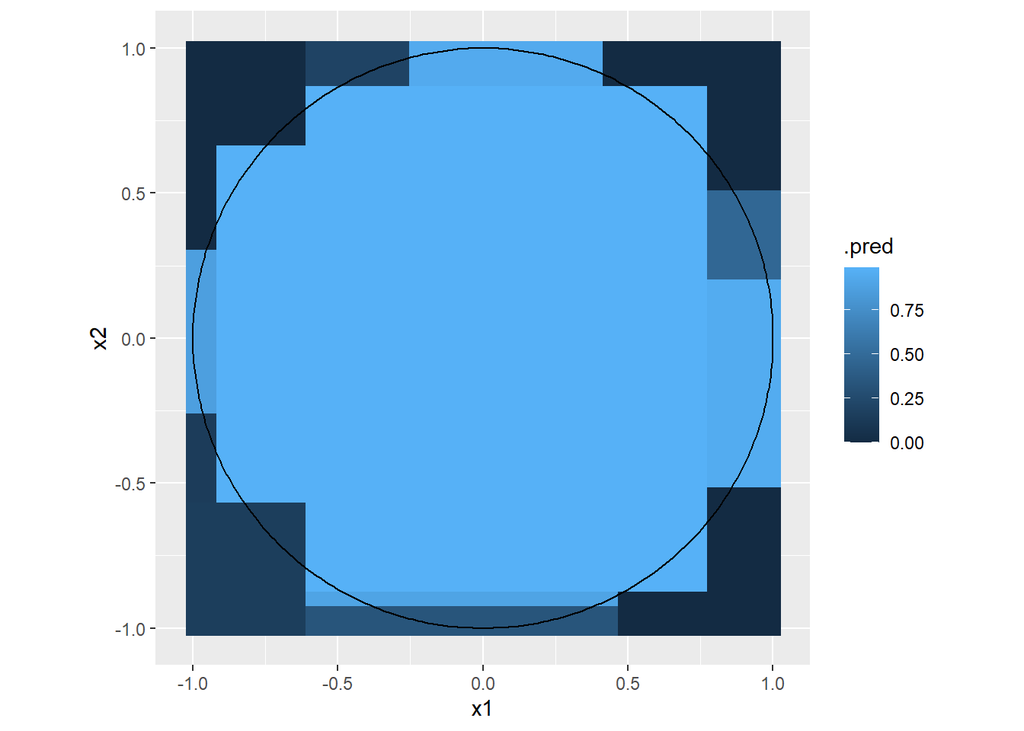

```r
df3.2=expand_grid(x1=seq(-1,1,length.out=40),x2=seq(-1,1,length.out=40))
df3.2|>mutate(.pred=predict(mod3,df3.2))|>ggplot(aes(x=x1,y=x2,fill=.pred))+geom_raster()+coord_fixed()+ggforce::geom_circle(data=data.frame(x0=0,y0=0,r=1),mapping=aes(x0=x0,y0=y0,r=r),inherit.aes=FALSE)
```

### Exercise 4.

Consider `Boston` dataset from the `MASS` library (accessible through `MASS::Boston`). The aim is to predict `medv` (median value of owner occupied homes in 1000USD).

- use `initial_split` to divide the dataset to training and model comparison parts (proportion 0.7)
- Use the training set to determine the best decision tree and compute it’s rmse on the model comparison data
- Use the ideas from the previous lab to determine the best kNN method which uses all variables (use 5-fold crossvalidation on training data for selecting parameters). Compute it’s performance on the model comparison data
- Fit the best kNN method which uses 5 most important variables (from tree method) and compute it’s performance on the model comparison data
- Compare all models with each other

```r
set.seed(20241031)
split=initial_split(MASS::Boston,prop=0.7)
train=training(split)
validate=testing(split)
```

```r
mod4_tree=rpart::rpart(medv~.,data=train,cp=0.0001)
cp_min=as_tibble(mod4_tree$cptable)|>filter(xerror==min(xerror))|>slice(1)|>pull(CP)
mod4_tree_final=rpart::prune(mod4_tree,cp=cp_min)
validate|>mutate(.pred=predict(mod4_tree_final,validate))|>rmse(truth=medv,estimate=.pred)
```

| .metric | .estimator | .estimate |
| --- | --- | --- |
| rmse | standard | 4.341946 |

```r
cv_data=vfold_cv(train,v=5)
knn_spec=nearest_neighbor(mode="regression",neighbors=tune(),dist_power=tune())
  wf4b=workflow()|>add_model(knn_spec)|>add_recipe(recipe(medv~.,data=train))
  tuning_grid=expand_grid(neighbors=c(5,10,20,40),dist_power=c(0.5,1,2))
  mod4b_tuning=wf4b|>tune_grid(cv_data,metrics=metric_set(rmse),grid=tuning_grid)
  show_best(mod4b_tuning,metric="rmse")
```

| neighbors | dist_power | .metric | .estimator | mean | n | std_err | .config |
| --- | --- | --- | --- | --- | --- | --- | --- |
| 5 | 2 | rmse | standard | 4.234873 | 5 | 0.4314732 | Preprocessor1_Model09 |
| 10 | 2 | rmse | standard | 4.271783 | 5 | 0.4288117 | Preprocessor1_Model10 |
| 5 | 1 | rmse | standard | 4.362462 | 5 | 0.5443816 | Preprocessor1_Model05 |
| 10 | 1 | rmse | standard | 4.444689 | 5 | 0.4991034 | Preprocessor1_Model06 |
| 20 | 2 | rmse | standard | 4.491553 | 5 | 0.4536247 | Preprocessor1_Model11 |

```r
wf4b|>finalize_workflow(select_best(mod4b_tuning,metric="rmse"))|>last_fit(split)|>collect_metrics()
```

| .metric | .estimator | .estimate | .config |
| --- | --- | --- | --- |
| rmse | standard | 4.6675183 | Preprocessor1_Model1 |
| rsq | standard | 0.7854695 | Preprocessor1_Model1 |

```r
wf4c=workflow()|>add_model(knn_spec)|>add_recipe(recipe(medv~lstat+rm+age+crim+indus,data=train))
  tuning_grid=expand_grid(neighbors=c(5,10,20,40),dist_power=c(0.5,1,2))
  mod4c_tuning=wf4c|>tune_grid(cv_data,metrics=metric_set(rmse),grid=tuning_grid)
  show_best(mod4c_tuning,metric="rmse")
```

| neighbors | dist_power | .metric | .estimator | mean | n | std_err | .config |
| --- | --- | --- | --- | --- | --- | --- | --- |
| 10 | 1 | rmse | standard | 4.112012 | 5 | 0.4702409 | Preprocessor1_Model06 |
| 10 | 2 | rmse | standard | 4.120354 | 5 | 0.4343555 | Preprocessor1_Model10 |
| 5 | 1 | rmse | standard | 4.134731 | 5 | 0.4094994 | Preprocessor1_Model05 |
| 5 | 2 | rmse | standard | 4.206349 | 5 | 0.3901256 | Preprocessor1_Model09 |
| 20 | 2 | rmse | standard | 4.223360 | 5 | 0.4932741 | Preprocessor1_Model11 |

```r
wf4c|>finalize_workflow(select_best(mod4c_tuning,metric="rmse"))|>last_fit(split)|>collect_metrics()
```

| .metric | .estimator | .estimate | .config |
| --- | --- | --- | --- |
| rmse | standard | 4.2894596 | Preprocessor1_Model1 |
| rsq | standard | 0.8139778 | Preprocessor1_Model1 |